# Lab 5 - Time-varying productivity of salmon

### $\alpha_t$, $\delta_t$ plots and the AICc.

What is the mean level of productivity? Plot the ts of $\delta_t$ and note the AICc for this model.

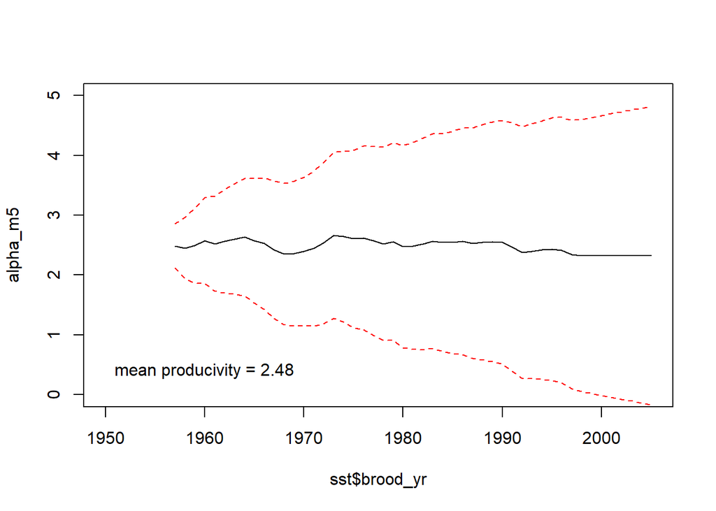

```r
alpha_m5 <- as.numeric(m5$states[1,])
alpha_m5_se <- as.numeric(m5$states.se[1,])

sst_m5 <- as.numeric(m5$states[3,])
sst_m5_se <- as.numeric(m5$states.se[3,])

mean_produc_m5 <- mean(alpha_m5)

# Alpha plot
plot(alpha_m5~sst$brood_yr,type='l', ylim = c(0,5),xlim= c(1950, 2005))
lines((alpha_m5+2*alpha_m5_se)~sst$brood_yr, lty="dashed", col="red")
lines(alpha_m5-2*alpha_m5_se~sst$brood_yr, lty="dashed", col="red")
text(1960, 0.4, "mean producivity = 2.48")
```

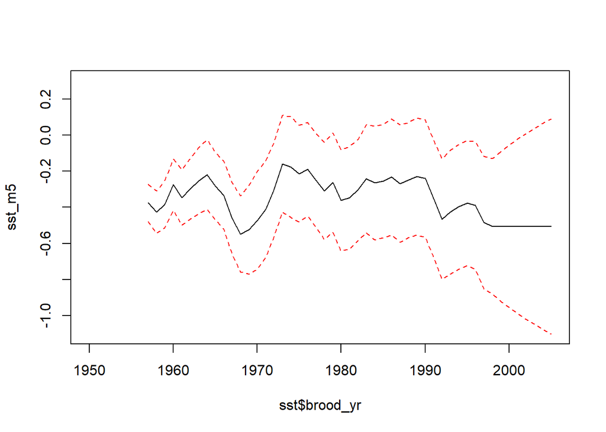

```r
# Delta plot
plot(sst_m5~sst$brood_yr,type='l',ylim = c(-1.1, 0.3), xlim= c(1950, 2005))
lines((sst_m5+2*sst_m5_se)~sst$brood_yr, lty="dashed", col="red")
lines(sst_m5-2*sst_m5_se~sst$brood_yr, lty="dashed", col="red")
```

```r
#AIC value
m5$AICc
```

```
## [1] 112.3449
```

The mean level of productivity in this model was 2.48. We found that this model did not test higher than the reduced Ricker model.

### Model Diagnostics

Also plot appropriate model diagnostics.

```
## MARSSresiduals.tt1 reported warnings. See msg element of returned residuals object.
## MARSSresiduals.tT reported warnings. See msg element or attribute of returned residuals object.
```

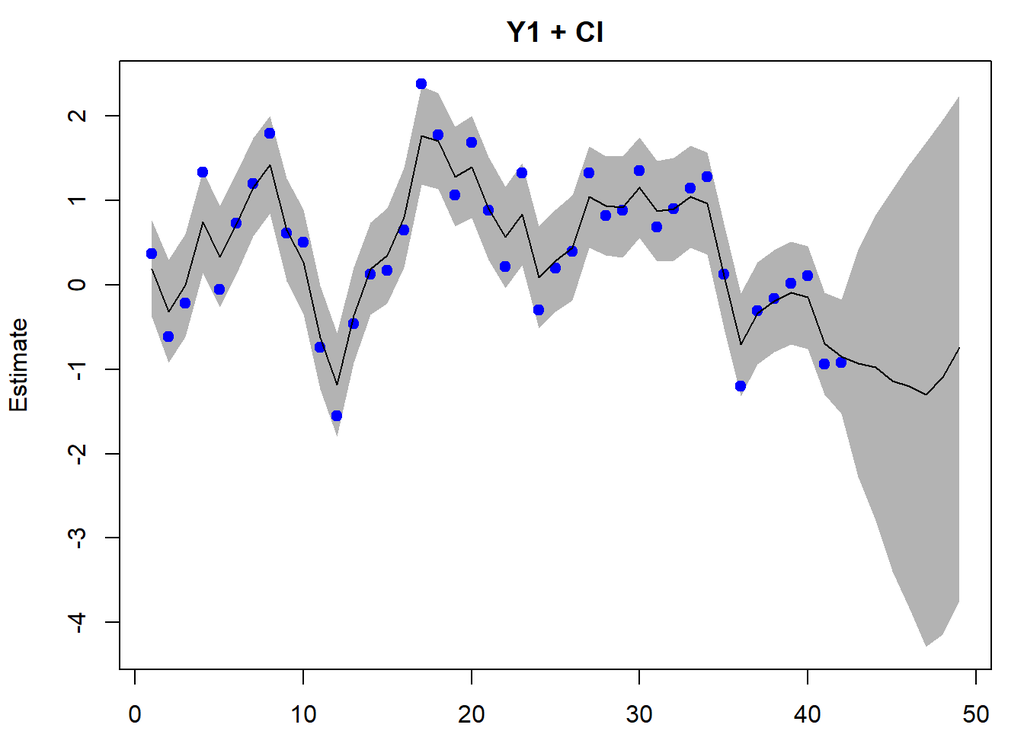

```
## plot type =  fitted.ytT  Observations with fitted values
## Hit <Return> to see next plot (q to exit):
```

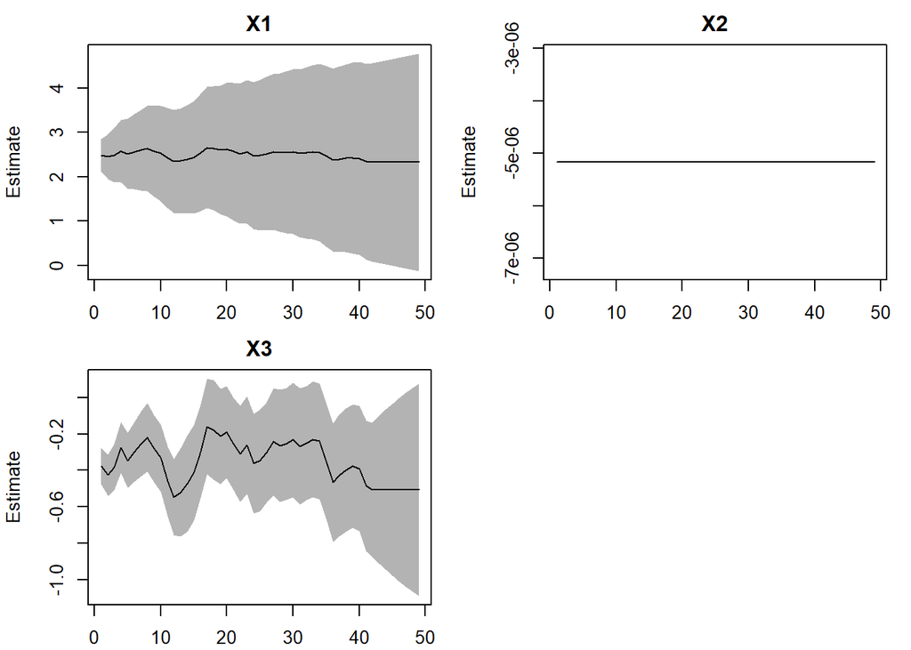

```
## plot type = xtT Estimated states
## Hit <Return> to see next plot (q to exit):
```

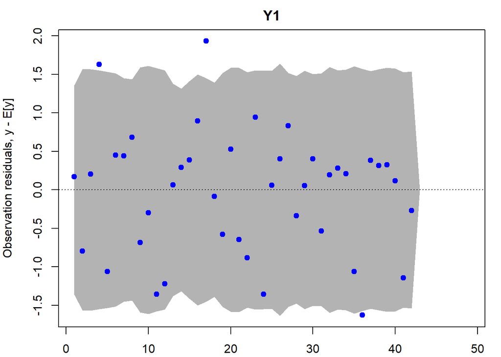

```
## plot type = model.resids.ytt1
## Hit <Return> to see next plot (q to exit):
```

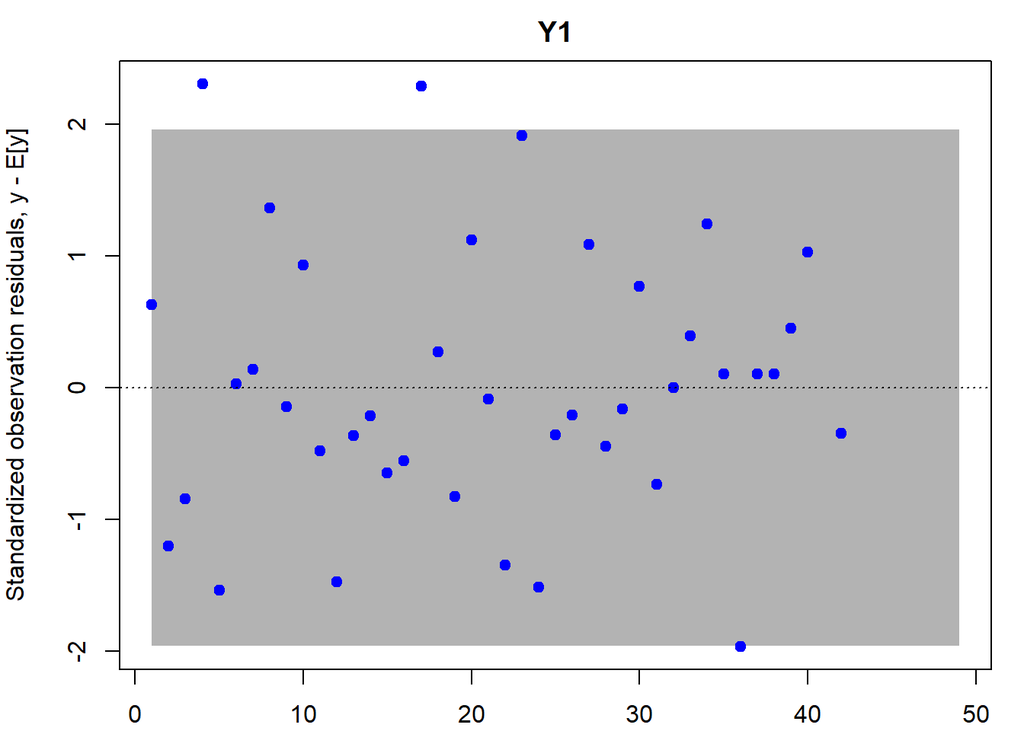

```
## plot type = std.model.resids.ytT
## Hit <Return> to see next plot (q to exit):
```

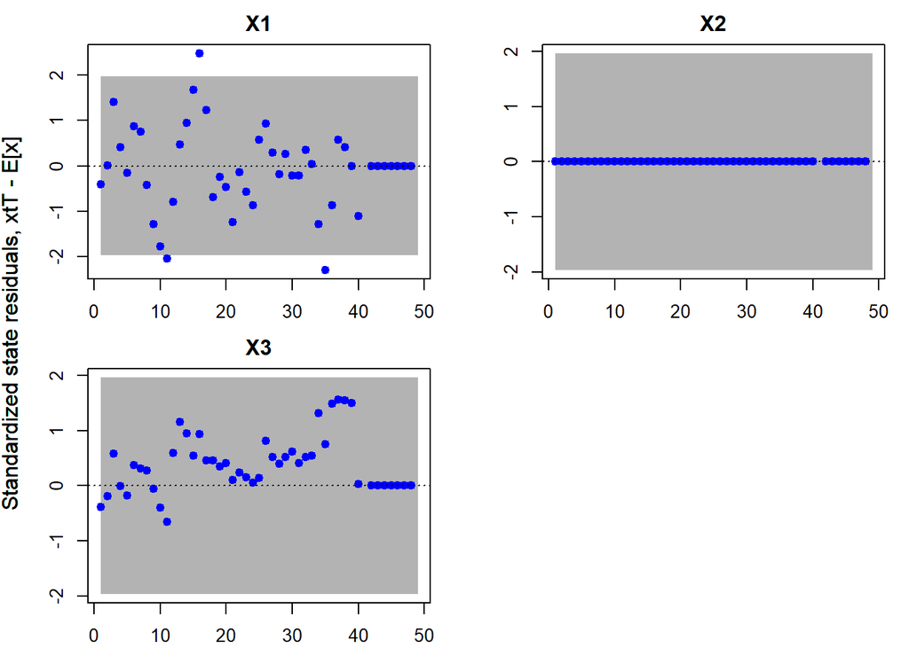

```
## plot type = std.state.resids.xtT
## Hit <Return> to see next plot (q to exit):
```

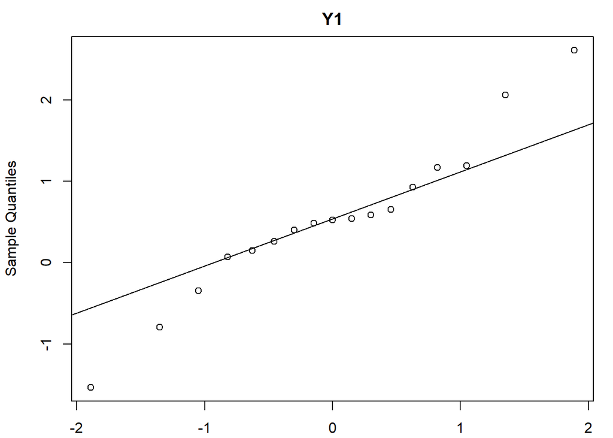

```
## plot type = qqplot.std.model.resids.ytt1
## Hit <Return> to see next plot (q to exit):
```

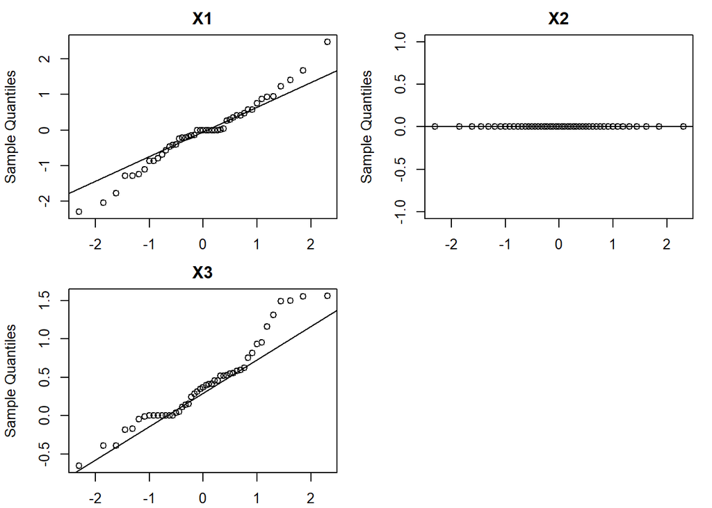

```
## plot type = qqplot.std.state.resids.xtT
## Hit <Return> to see next plot (q to exit):
```

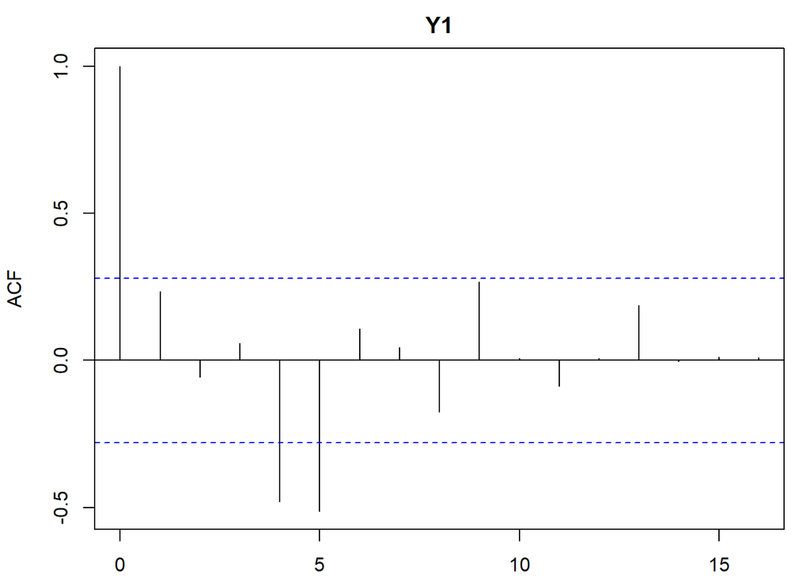

```
## plot type = acf.std.model.resids.ytt1
```

```r
plot(m5)
```

# Discussion

We found that the Kvichak sockeye spawner recruit time series was best explained by the simplest model with just a time varying intercept. Of the three covariates (summer pdo, winter pdo and SST) we tested, the model with SST had the lowest AIC but not lower than the simplest model. We found that the effect of summer and winter pdo were not time varying. This might be because a time varying intercept explained most of the variance.

# Team contributions

Dylan wrote the original code for reduced ricker and full ricker models. Maria wrote the code for the PDO models. Liz wrote the code for the SST and coded the models in matrix form. All team members contributed to writing and organization of the lab document.